# Basic Unix Commands - File System

# The File

- UNIX treats everything as a file... Directories and devices like the hard disk, DVD-ROM, and printer are files to UNIX.
- Three types of files
  1. Ordinary file
     - Also known as a regular file, contains only data as a stream of characters.
  2. Directory file
     - A folder containing the names of other files and subdirectories.
  3. Device file
     - Represents a device or peripheral.

# The File System Hierarchy

UNIX files are organized in a hierarchical (an inverted tree) structure, starting with root (`/`)

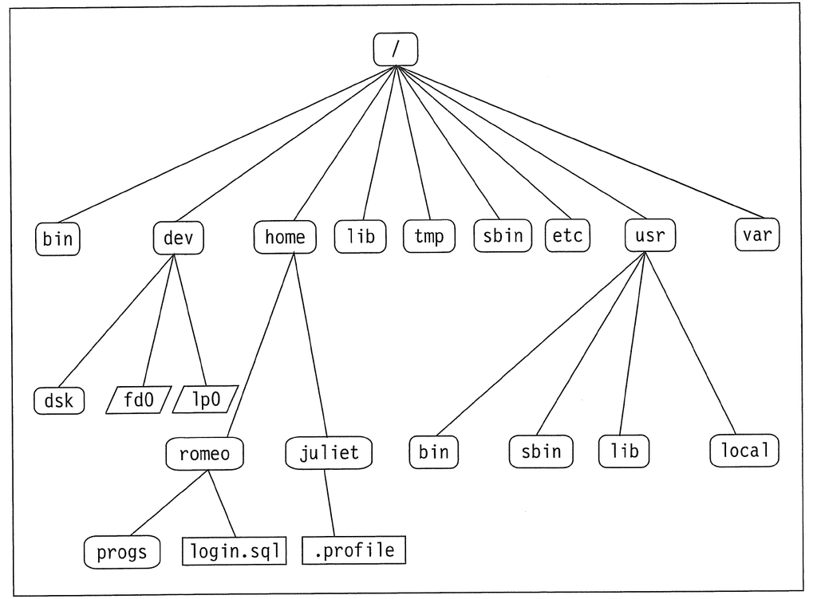

```python
import IPython.display
IPython.display.Image(filename='images/tree.png', embed=True, width=500)
```

Image Source: S. Das. *Your UNIX/Linux: The Ultimate Guide.* Third. McGraw-Hill, Inc.,

# Relative Pathnames

### Relative path shortcuts

- `.` (a single dot) represents the current directory
- `..` (two dots) represents the parent directory

### Example

```
> pwd /home
> ls .
  john george
> cd john $ pwd
  /home/john
> cd ..
> pwd /home
```

# Making and removing directories

### Making directories

```
>mkdir myDir
```

(UNIX is case sensitive by-the-way) creates a directory myDir in the current directory

```
>mkdir myDir1 myDir2
```

Creates multiple directories in one command

```
>mkdir myDir1/myDir2
```

creates `myDir2` inside of `myDir1` (must exist)

### Removing directories

```
rmdir myDir
```

Only works for empty directories. (No other files/directories inside)

```
rm -R myDir
```

Use will caution! You **CANNOT** recover from `rm`

# Copy and Move

### cp -- copy

```
>cp file1 file2
```

Copies `file1` to `file2`

```
>cp -R myDir1 myDir2
```

`-R` option copies recursively, meaning all subdirectories will be copied as well

### mv - move

```
>mv file1 file2
```

When used this way it’s basically a rename utility

```
>mv file1 file2 myDir
```

Moves `file1` and `file2` into the directory `myDir`

# Deleting files

```
>rm file1 file2
```

```
>rm file*
```

`*` is a wildcard, meaning anything, the command will remove all patterns that match file with anything following.

**Can be dangerous.** With the right permissions `rm -Rf /*` would remove most of the files on your hard drive without warning.

Protect yourself `rm -i`

[figure not shown]